# Flight Delay Analysis

Irena Austin

2026-04-08

**Part 1**  
Load Libraries  
“Force-load” to prevent it from crashing when running the code and used pacman to load all libraries./ Loaded parquet data from my drive.

```r
# Force-load
if (!require("mvtnorm")) install.packages("mvtnorm")
if (!require("FactoMineR")) install.packages("FactoMineR")

library(mvtnorm)
library(FactoMineR)

# Load all other required libraries
pacman::p_load(
  tidyverse, janitor, lubridate, skimr, caret, glmnet,
  broom, ggplot2, knitr, kableExtra, arrow, corrplot,
  rpart, rpart.plot, randomForest, ranger,
  e1071, nnet, kernlab, factoextra
)

# Load the full Parquet file
flights_raw <- open_dataset("C:/Users/ZyrIr/OneDrive/Desktop/flights_canonical_2019.parquet") %>%
  collect() %>%
  clean_names()
```

**Part 2**  
Clean Data  
Defined holidays (used Jonathan dates with the 3 +/- days). Unix Epoch (1970-01-01) standard./ Filtered flights going to JFK/EWR from BWI./ Used FAA 15 minute rule to verify if flight delayed: Yes/No. Then Looked at buffers, time of day, and tried to separate by smaller/larger planes based on distance.

```r
# Define 2019 Federal Holidays
us_holidays_2019 <- as.Date(c(
  "2019-01-01", "2019-01-21", "2019-02-18", "2019-05-27",
  "2019-07-04", "2019-09-02", "2019-10-14", "2019-11-11",
  "2019-11-28", "2019-12-25"
))

# Generate travel windows (+/- 3 days around each holiday)
holiday_windows <- map(us_holidays_2019, ~ seq(.x - 3, .x + 3, by = "day")) %>%
  flatten_dbl() %>%
  as.Date(origin = "1970-01-01")

df_final <- flights_raw %>%
  filter(origin == "BWI", dest %in% c("JFK", "EWR")) %>%
  select(
    flight_date, arr_delay, dep_delay, carrier_delay, weather_delay,
    dep_hour_local, day_of_week, month,
    dep_temp_c, dep_wind_speed_m_s, dep_ceiling_height_m,
    reporting_airline, taxi_out,
    prev_arr_delay, turnaround_minutes, aircraft_leg_number_day,
    crs_elapsed_time, actual_elapsed_time, distance
  ) %>%
  mutate(
    across(c(prev_arr_delay, weather_delay, carrier_delay), ~replace_na(., 0)),
    flight_date_clean = as.Date(flight_date)
  ) %>%
  filter(!is.na(arr_delay), !is.na(dep_delay)) %>%
  mutate(
    is_delayed   = as.factor(ifelse(arr_delay >= 15, "Yes", "No")),
    is_weekend   = as.factor(ifelse(day_of_week %in% c(6, 7), "Yes", "No")),
    is_rush_hour = as.factor(ifelse(dep_hour_local %in% c(7, 8, 16, 17, 18), "Yes", "No")),
    reporting_airline = as.factor(reporting_airline),
    buffer = crs_elapsed_time - actual_elapsed_time,
    is_holiday = as.factor(ifelse(flight_date_clean %in% holiday_windows, "Holiday", "Non-Holiday")),
    plane_size_score = case_when(
      distance > 1500 ~ "Large",
      distance > 500  ~ "Medium",
      TRUE            ~ "Small"
    )
  )

# Output Holiday Frequency Table
table(df_final$is_holiday)
```

```
##
##     Holiday Non-Holiday
##         290        1497
```

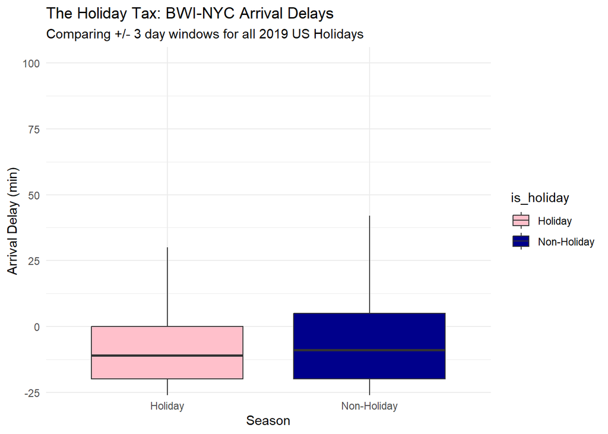

```r
# Visualize Arrival Delays by Holidays
ggplot(df_final, aes(x = is_holiday, y = arr_delay, fill = is_holiday)) +
  geom_boxplot(outlier.shape = NA) +
  coord_cartesian(ylim = c(-20, 100)) +
  scale_fill_manual(values = c("Holiday" = "pink", "Non-Holiday" = "darkblue")) +
  labs(title = "The Holiday Tax: BWI-NYC Arrival Delays",
       subtitle = "Comparing +/- 3 day windows for all 2019 US Holidays",
       x = "Season", y = "Arrival Delay (min)") +
  theme_minimal()
```

**Part 4**  
Principal Component Analysis (PCA)  
scaling to turn each value into a score to compare all together; helps to reduce the noise of all the data.

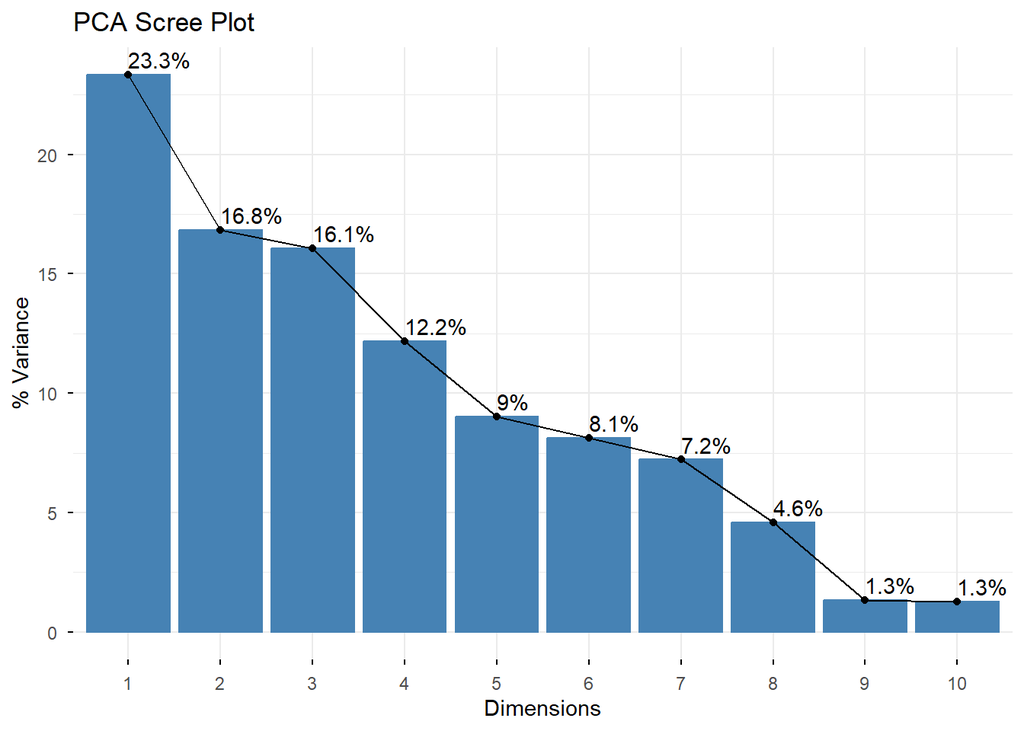

```r
# Standardize numeric inputs
df_pca_input <- df_final %>%
  select(dep_delay, dep_hour_local, dep_wind_speed_m_s, dep_temp_c,
         dep_ceiling_height_m, prev_arr_delay, turnaround_minutes,
         aircraft_leg_number_day, buffer, distance, taxi_out) %>%
  drop_na() %>%
  scale() %>%
  as.data.frame()

# Execute PCA via FactoMineR
pca_result <- FactoMineR::PCA(df_pca_input, graph = FALSE)

# Scree Plot
factoextra::fviz_eig(pca_result, addlabels = TRUE) +
  labs(title = "PCA Scree Plot", y = "% Variance")
```

```r
# Extract top 5 components for nonlinear modeling
pca_scores <- as.data.frame(pca_result$ind$coord[, 1:5])
df_pca_model <- bind_cols(is_delayed = df_final$is_delayed[1:nrow(pca_scores)], pca_scores)
```

**Part 5**  
Tree Modeling

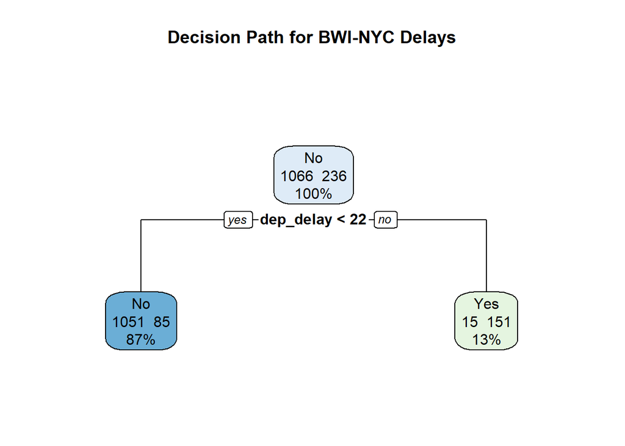

```r
set.seed(42)

# Select features for the original coordinate system
df_model <- df_final %>%
  select(is_delayed, dep_delay, dep_hour_local, dep_wind_speed_m_s,
         aircraft_leg_number_day, plane_size_score, is_holiday, is_weekend) %>%
  drop_na()

train_idx <- createDataPartition(df_model$is_delayed, p = 0.75, list = FALSE)
train_set <- df_model[train_idx, ]
test_set  <- df_model[-train_idx, ]

# Decision Tree
tree_fit <- rpart(is_delayed ~ ., data = train_set, method = "class")
rpart.plot(tree_fit, extra = 101, main = "Decision Path for BWI-NYC Delays")
```

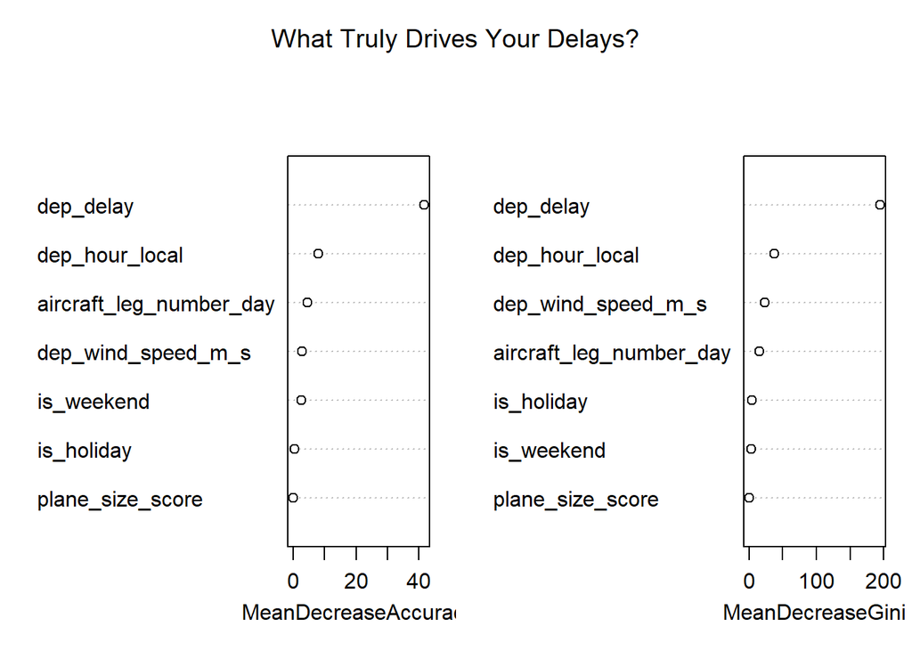

```r
# Random Forest
rf_fit <- randomForest(is_delayed ~ ., data = train_set, ntree = 100, importance = TRUE)
varImpPlot(rf_fit, main = "What Truly Drives Your Delays?")
```

**Part 6**  
Non Linear Modeling

```r
# Split PCA data
pca_train_idx <- createDataPartition(df_pca_model$is_delayed, p = 0.75, list = FALSE)
train_pca <- df_pca_model[pca_train_idx, ]
test_pca  <- df_pca_model[-pca_train_idx, ]

# SVM (Radial Basis Function Kernel)
svm_fit <- kernlab::ksvm(is_delayed ~ ., data = train_pca, kernel = "rbfdot", C = 1)
svm_preds <- predict(svm_fit, test_pca)

# Neural Network (5 Hidden Neurons)
nnet_fit <- nnet::nnet(is_delayed ~ ., data = train_pca, size = 5, decay = 0.01, trace = FALSE)
nnet_preds <- as.factor(predict(nnet_fit, test_pca, type = "class"))

# Accuracy Comparison
cat("SVM Accuracy:", confusionMatrix(svm_preds, test_pca$is_delayed)$overall["Accuracy"], "\n")
```

```
## SVM Accuracy: 0.8232558
```

```r
cat("Neural Net Accuracy:", confusionMatrix(nnet_preds, test_pca$is_delayed)$overall["Accuracy"], "\n")
```

```
## Neural Net Accuracy: 0.8255814
```

.

```r
# Update is_holiday in df_final with named holiday categories
df_final <- df_final %>%
  mutate(
    is_holiday = as.factor(case_when(
      flight_date_clean >= (as.Date("2019-11-28") - 3) &
      flight_date_clean <= (as.Date("2019-11-28") + 3) ~ "Thanksgiving",

      flight_date_clean >= (as.Date("2019-12-25") - 3) &
      flight_date_clean <= (as.Date("2019-12-25") + 3) ~ "Christmas",

      flight_date_clean >= (as.Date("2019-07-04") - 3) &
      flight_date_clean <= (as.Date("2019-07-04") + 3) ~ "July4th",

      flight_date_clean %in% holiday_windows ~ "Other_Holiday",

      TRUE ~ "Non-Holiday"
    ))
  )

# Verify the distribution
table(df_final$is_holiday)
```

```
##
##     Christmas       July4th   Non-Holiday Other_Holiday  Thanksgiving
##            21            25          1497           214            30
```

**Part 8**  
Filtering  
Filter the data, looking at all large hubs by destination and flight number./

```r
# Filter for BWI flights
df_clean <- flights_raw %>%
  filter(origin == "BWI", dest %in% c("JFK", "EWR"))

# Count flights per destination
hub_counts <- flights_raw %>%
  group_by(dest) %>%
  summarise(
    total_flights = n(),
    unique_airlines = n_distinct(reporting_airline),
    avg_taxi_in = mean(taxi_in, na.rm = TRUE)
  ) %>%
  arrange(desc(total_flights))

head(hub_counts, 10)
```

```
## # A tibble: 10 × 4
##    dest  total_flights unique_airlines avg_taxi_in
##    <chr>         <int>           <int>       <dbl>
##  1 ATL          395026              15        8.87
##  2 ORD          339569              13       14.1
##  3 DFW          304346              14       11.8
##  4 DEN          252064              12        9.09
##  5 CLT          235490              14       12.5
##  6 LAX          219996              11       11.0
##  7 IAH          179682              14        8.79
##  8 PHX          175343              11        7.50
##  9 LGA          171665              14        9.04
## 10 SFO          170966               9        8.56
```

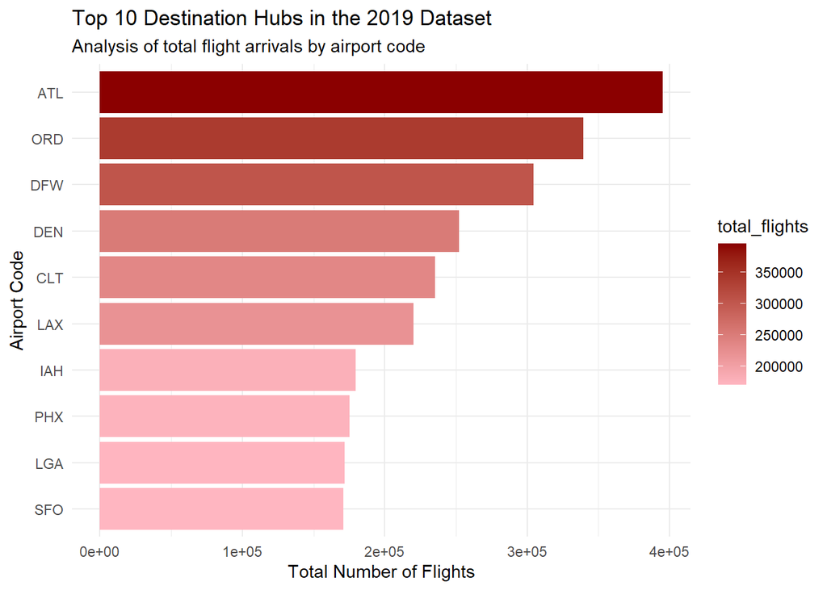

```r
# Top 10 Hubs Overall
ggplot(head(hub_counts, 10), aes(x = reorder(dest, total_flights), y = total_flights, fill = total_flights)) +
  geom_col() +
  coord_flip() +
  scale_fill_gradient(low = "lightpink", high = "darkred") +
  labs(
    title = "Top 10 Destination Hubs in the 2019 Dataset",
    subtitle = "Analysis of total flight arrivals by airport code",
    x = "Airport Code",
    y = "Total Number of Flights"
  ) +
  theme_minimal()
```

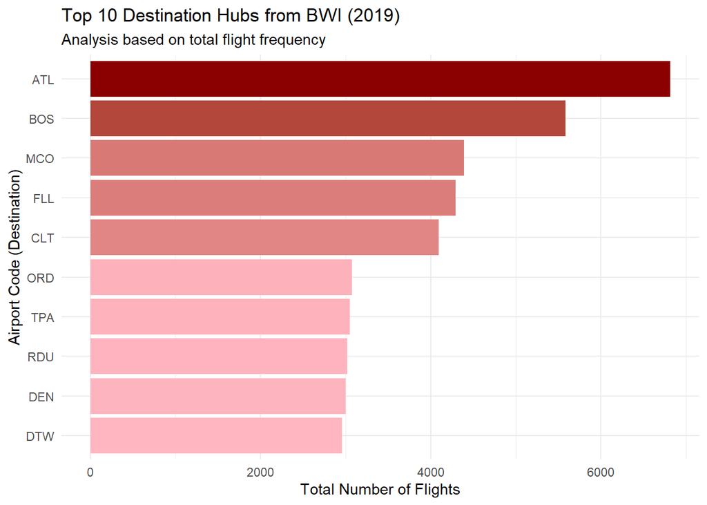

```r
# Top 10 Hubs from BWI
hub_data <- flights_raw %>%
  filter(origin == "BWI") %>%
  count(dest, sort = TRUE) %>%
  top_n(10, n)

ggplot(hub_data, aes(x = reorder(dest, n), y = n, fill = n)) +
  geom_col(show.legend = FALSE) +
  coord_flip() +
  scale_fill_gradient(low = "lightpink", high = "darkred") +
  labs(
    title = "Top 10 Destination Hubs from BWI (2019)",
    subtitle = "Analysis based on total flight frequency",
    x = "Airport Code (Destination)",
    y = "Total Number of Flights"
  ) +
  theme_minimal()
```

```r
# Airline Scheduling Honesty Check
honesty_check <- df_final %>%
  mutate(buffer = crs_elapsed_time - actual_elapsed_time) %>%
  group_by(reporting_airline) %>%
  summarise(
    avg_padding_mins = mean(buffer, na.rm = TRUE),
    avg_arrival_delay = mean(arr_delay, na.rm = TRUE),
    flight_count = n()
  ) %>%
  arrange(desc(avg_padding_mins))

kable(honesty_check, caption = "Airline Scheduling Honesty (Padding vs. Delay)") %>%
  kable_styling(bootstrap_options = c("striped", "hover"))
```

Airline Scheduling Honesty (Padding vs. Delay)

| reporting_airline | avg_padding_mins | avg_arrival_delay | flight_count |
| --- | --- | --- | --- |
| 9E | 6.491667 | 2.6969919 | 1363 |
| WN | 5.237288 | 22.9661017 | 59 |
| MQ | 4.461318 | -0.2109589 | 365 |

```r
# Airline Market Share
airline_counts <- flights_raw %>%
  group_by(reporting_airline) %>%
  summarise(total_flights = n()) %>%
  arrange(desc(total_flights))

head(airline_counts)
```

```
## # A tibble: 6 × 2
##   reporting_airline total_flights
##   <chr>                     <int>
## 1 WN                      1363946
## 2 DL                       991986
## 3 AA                       946776
## 4 OO                       836445
## 5 UA                       625910
## 6 YX                       329149
```

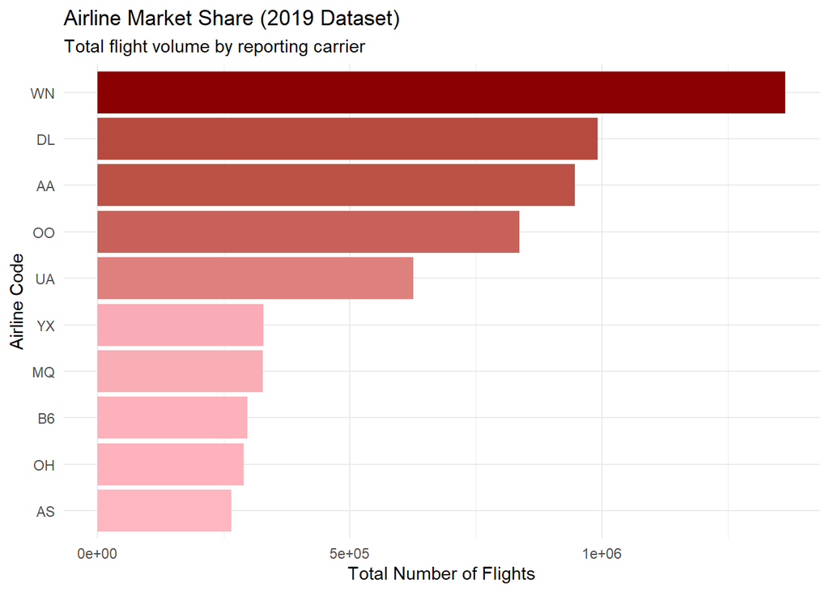

```r
ggplot(head(airline_counts, 10), aes(x = reorder(reporting_airline, total_flights), y = total_flights, fill = total_flights)) +
  geom_col(show.legend = FALSE) +
  coord_flip() +
  scale_fill_gradient(low = "lightpink", high = "darkred") +
  labs(
    title = "Airline Market Share (2019 Dataset)",
    subtitle = "Total flight volume by reporting carrier",
    x = "Airline Code",
    y = "Total Number of Flights"
  ) +
  theme_minimal()
```

```r
# Target Airline Buffer Analysis
target_airlines <- c("WN", "DL", "AA", "OO", "UA", "YX", "MQ", "B6", "OH", "AS")

airline_buffer_analysis <- df_final %>%
  filter(reporting_airline %in% target_airlines) %>%
  mutate(buffer_mins = crs_elapsed_time - actual_elapsed_time) %>%
  group_by(reporting_airline) %>%
  summarise(
    avg_padding = mean(buffer_mins, na.rm = TRUE),
    median_padding = median(buffer_mins, na.rm = TRUE),
    on_time_rate = mean(arr_delay <= 0, na.rm = TRUE) * 100,
    avg_arr_delay = mean(arr_delay, na.rm = TRUE),
    flight_count = n()
  ) %>%
  arrange(desc(avg_padding))

airline_buffer_analysis %>%
  knitr::kable(caption = "Airline Scheduling Buffer Analysis (2019)",
               digits = 2,
               col.names = c("Airline", "Avg Padding (min)", "Median Padding", "On-Time %", "Avg Delay", "Flights"))
```

Airline Scheduling Buffer Analysis (2019)

| Airline | Avg Padding (min) | Median Padding | On-Time % | Avg Delay | Flights |
| --- | --- | --- | --- | --- | --- |
| WN | 5.24 | 10 | 42.37 | 22.97 | 59 |
| MQ | 4.46 | 8 | 72.88 | -0.21 | 365 |

```r
# All Airline Buffer Analysis
all_airline_buffers <- flights_raw %>%
  filter(!is.na(crs_elapsed_time), !is.na(actual_elapsed_time)) %>%
  mutate(buffer_mins = crs_elapsed_time - actual_elapsed_time) %>%
  group_by(reporting_airline) %>%
  summarise(
    avg_buffer_mins = mean(buffer_mins, na.rm = TRUE),
    median_buffer   = median(buffer_mins, na.rm = TRUE),
    flight_count    = n(),
    on_time_arrival_rate = mean(arr_delay <= 0, na.rm = TRUE) * 100
  ) %>%
  filter(flight_count > 100) %>%
  arrange(desc(avg_buffer_mins))

print(all_airline_buffers)
```

```
## # A tibble: 17 × 5
##    reporting_airline avg_buffer_mins median_buffer flight_count
##    <chr>                       <dbl>         <dbl>        <int>
##  1 WN                          7.57              8      1327562
##  2 9E                          7.08              9       252348
##  3 DL                          6.91              8       988025
##  4 B6                          6.37              8       292724
##  5 NK                          5.79              7       200891
##  6 F9                          5.79              8       133061
##  7 OO                          5.29              7       815839
##  8 AA                          5.06              7       924242
##  9 UA                          4.62              7       618707
## 10 OH                          3.89              5       281647
## 11 YX                          3.76              6       320615
## 12 AS                          3.61              4       261015
## 13 YV                          3.28              5       220586
## 14 MQ                          2.27              4       314658
## 15 G4                          2.09              3       104443
## 16 EV                          1.60              4       128180
## 17 HA                          0.626             1        83689
## # ℹ 1 more variable: on_time_arrival_rate <dbl>
```

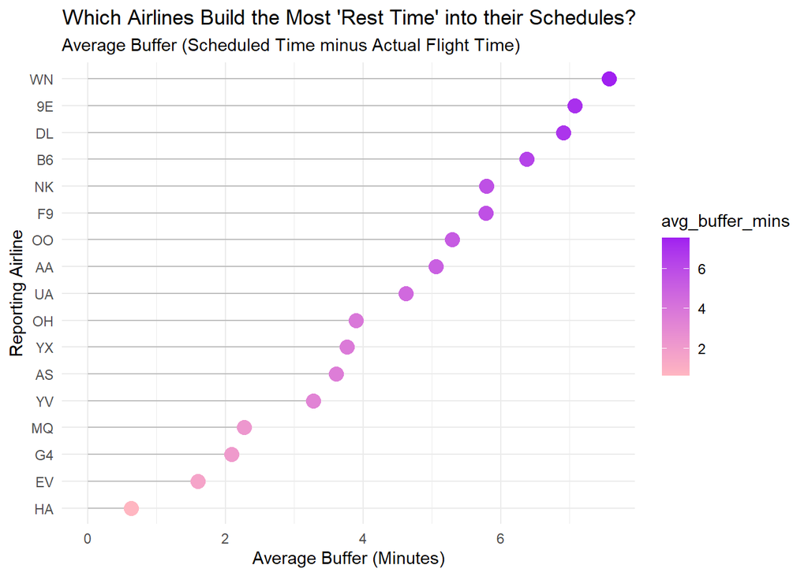

```r
ggplot(all_airline_buffers, aes(x = reorder(reporting_airline, avg_buffer_mins), y = avg_buffer_mins)) +
  geom_segment(aes(xend = reporting_airline, yend = 0), color = "grey") +
  geom_point(size = 4, aes(color = avg_buffer_mins)) +
  scale_color_gradient(low = "lightpink", high = "purple") +
  coord_flip() +
  labs(
    title = "Which Airlines Build the Most 'Rest Time' into their Schedules?",
    subtitle = "Average Buffer (Scheduled Time minus Actual Flight Time)",
    x = "Reporting Airline",
    y = "Average Buffer (Minutes)"
  ) +
  theme_minimal()
```

```r
# Weekday vs Weekend Buffer Comparison
weekend_comparison <- df_final %>%
  mutate(
    buffer_mins = crs_elapsed_time - actual_elapsed_time,
    day_type = ifelse(day_of_week %in% c(6, 7), "Weekend", "Weekday")
  ) %>%
  group_by(reporting_airline, day_type) %>%
  summarise(
    avg_buffer = mean(buffer_mins, na.rm = TRUE),
    avg_arr_delay = mean(arr_delay, na.rm = TRUE),
    flight_count = n()
  ) %>%
  arrange(reporting_airline, day_type)

print(weekend_comparison)
```

```
## # A tibble: 6 × 5
## # Groups:   reporting_airline [3]
##   reporting_airline day_type avg_buffer avg_arr_delay flight_count
##   <fct>             <chr>         <dbl>         <dbl>        <int>
## 1 9E                Weekday        7.03          4.15          988
## 2 9E                Weekend        5.07         -1.14          375
## 3 MQ                Weekday        4.30          2.21          261
## 4 MQ                Weekend        4.88         -6.29          104
## 5 WN                Weekday        5.22         24.7            46
## 6 WN                Weekend        5.31         16.9            13
```

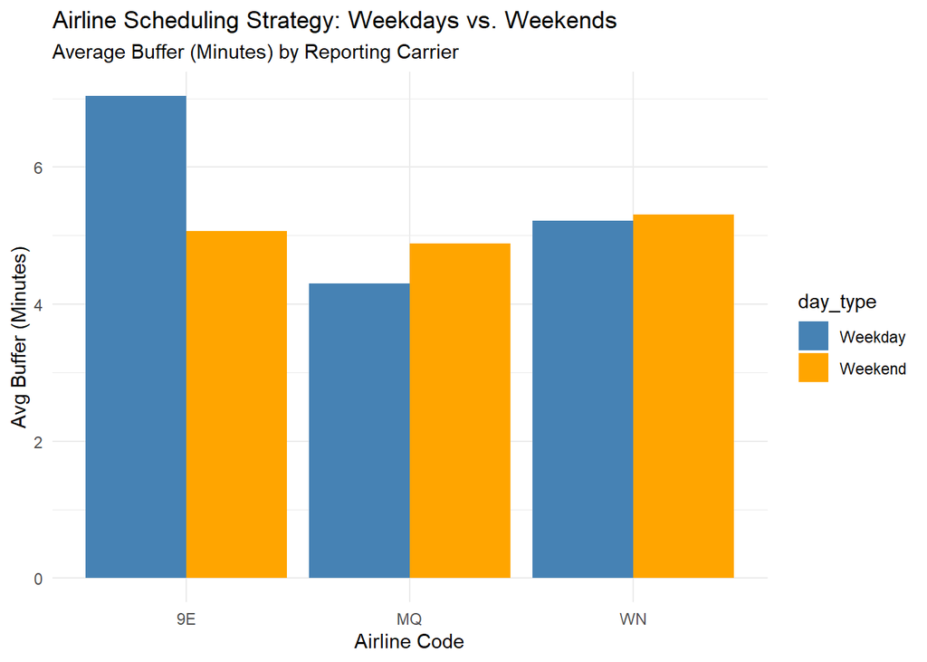

```r
ggplot(weekend_comparison, aes(x = reporting_airline, y = avg_buffer, fill = day_type)) +
  geom_bar(stat = "identity", position = "dodge") +
  scale_fill_manual(values = c("Weekday" = "steelblue", "Weekend" = "orange")) +
  labs(
    title = "Airline Scheduling Strategy: Weekdays vs. Weekends",
    subtitle = "Average Buffer (Minutes) by Reporting Carrier",
    x = "Airline Code",
    y = "Avg Buffer (Minutes)"
  ) +
  theme_minimal()
```

**Part 9**  
Holiday Impact  
Looked at the whole dataset again.

```r
# re-run the named holiday tagging on the full flights_raw dataset
# all routes
flights_holiday <- flights_raw %>%
  filter(!is.na(arr_delay), !is.na(dep_delay)) %>%
  mutate(
    flight_date_clean = as.Date(flight_date),
    is_holiday = as.factor(case_when(
      flight_date_clean >= (as.Date("2019-11-28") - 3) &
      flight_date_clean <= (as.Date("2019-11-28") + 3) ~ "Thanksgiving",

      flight_date_clean >= (as.Date("2019-12-25") - 3) &
      flight_date_clean <= (as.Date("2019-12-25") + 3) ~ "Christmas",

      flight_date_clean >= (as.Date("2019-07-04") - 3) &
      flight_date_clean <= (as.Date("2019-07-04") + 3) ~ "July_4th",

      flight_date_clean %in% holiday_windows ~ "Other_Holiday",
      TRUE ~ "Non-Holiday"
    )),
    # Reorder factor so Non-Holiday is the baseline reference
    is_holiday = factor(is_holiday, levels = c(
      "Non-Holiday", "Thanksgiving", "Christmas", "July_4th", "Other_Holiday"
    ))
  )

# average delays by holiday
holiday_airline_summary <- flights_holiday %>%
  group_by(reporting_airline, is_holiday) %>%
  summarise(
    avg_arr_delay  = mean(arr_delay,  na.rm = TRUE),
    avg_dep_delay  = mean(dep_delay,  na.rm = TRUE),
    pct_delayed    = mean(arr_delay >= 15, na.rm = TRUE) * 100,
    flight_count   = n(),
    .groups = "drop"
  )

# Print the full summary
kable(holiday_airline_summary,
      caption = "Holiday Impact on Delays by Airline (All Routes, 2019)",
      digits = 2,
      col.names = c("Airline", "Holiday Period", "Avg Arr Delay",
                    "Avg Dep Delay", "% Flights Delayed (≥15 min)", "Flights")) %>%
  kable_styling(bootstrap_options = c("striped", "hover", "condensed")) %>%
  column_spec(5, bold = TRUE)
```

Holiday Impact on Delays by Airline (All Routes, 2019)

| Airline | Holiday Period | Avg Arr Delay | Avg Dep Delay | % Flights Delayed (≥15 min) | Flights |
| --- | --- | --- | --- | --- | --- |
| 9E | Non-Holiday | 3.04 | 10.07 | 17.29 | 213815 |
| 9E | Thanksgiving | -1.31 | 6.31 | 14.77 | 4481 |
| 9E | Christmas | -6.64 | 5.66 | 10.81 | 5015 |
| 9E | July_4th | 3.78 | 11.84 | 14.82 | 3704 |
| 9E | Other_Holiday | 4.92 | 11.27 | 18.37 | 30117 |
| AA | Non-Holiday | 6.80 | 11.82 | 20.58 | 777018 |
| AA | Thanksgiving | 4.33 | 9.18 | 19.38 | 17159 |
| AA | Christmas | 3.29 | 10.60 | 19.15 | 17504 |
| AA | July_4th | 12.75 | 18.09 | 24.77 | 16899 |
| AA | Other_Holiday | 6.79 | 11.85 | 20.60 | 118196 |
| AS | Non-Holiday | 1.57 | 5.10 | 18.49 | 216795 |
| AS | Thanksgiving | 3.32 | 7.69 | 21.27 | 5008 |
| AS | Christmas | 9.00 | 13.90 | 27.20 | 5117 |
| AS | July_4th | -0.79 | 3.50 | 14.95 | 5510 |
| AS | Other_Holiday | -1.45 | 2.61 | 15.44 | 32386 |
| B6 | Non-Holiday | 10.54 | 17.12 | 24.84 | 242951 |
| B6 | Thanksgiving | 9.57 | 13.96 | 24.39 | 5929 |
| B6 | Christmas | 5.56 | 14.84 | 19.67 | 5703 |
| B6 | July_4th | 16.00 | 23.64 | 26.32 | 5596 |
| B6 | Other_Holiday | 14.69 | 20.26 | 26.15 | 37232 |
| DL | Non-Holiday | 1.02 | 7.99 | 14.28 | 823562 |
| DL | Thanksgiving | 2.88 | 8.07 | 17.06 | 17495 |
| DL | Christmas | -0.48 | 8.83 | 16.12 | 16648 |
| DL | July_4th | 1.79 | 7.91 | 13.71 | 17276 |
| DL | Other_Holiday | 2.20 | 9.12 | 14.84 | 117005 |
| EV | Non-Holiday | 14.90 | 16.51 | 24.63 | 110361 |
| EV | Thanksgiving | 9.88 | 13.04 | 19.74 | 2665 |
| EV | Christmas | -2.84 | 4.90 | 11.84 | 2315 |
| EV | July_4th | 22.83 | 23.81 | 27.28 | 2203 |
| EV | Other_Holiday | 15.97 | 17.20 | 26.03 | 17139 |

[output cut: 55 more lines]

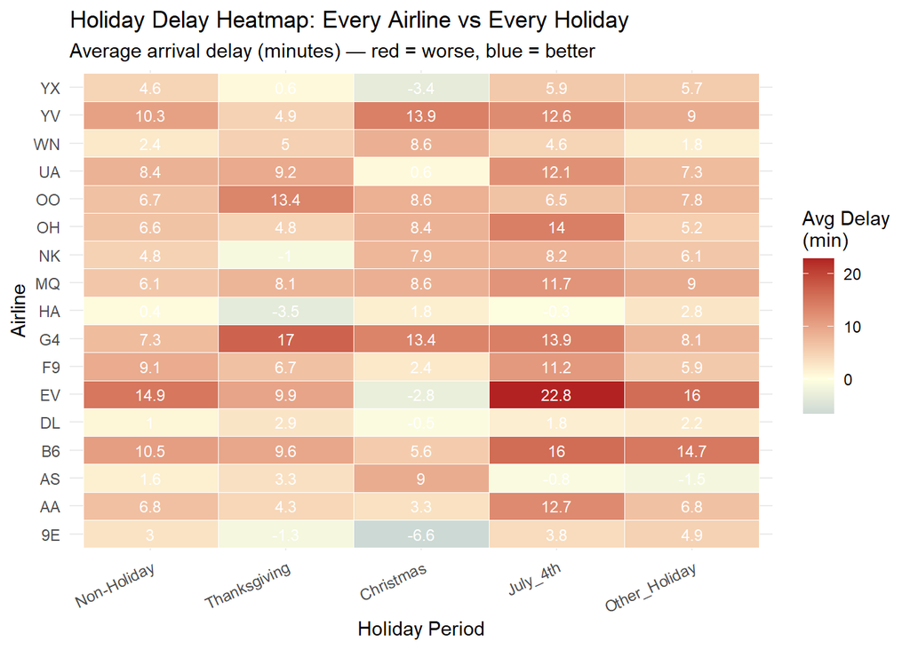

```r
# Heatmap of Avg Arrival Delay by Airline × Holiday
ggplot(holiday_airline_summary,
       aes(x = is_holiday, y = reporting_airline, fill = avg_arr_delay)) +
  geom_tile(color = "white") +
  geom_text(aes(label = round(avg_arr_delay, 1)), size = 3, color = "white") +
  scale_fill_gradient2(
    low = "steelblue", mid = "lightyellow", high = "firebrick",
    midpoint = 0, name = "Avg Delay\n(min)"
  ) +
  labs(
    title = "Holiday Delay Heatmap: Every Airline vs Every Holiday",
    subtitle = "Average arrival delay (minutes) — red = worse, blue = better",
    x = "Holiday Period", y = "Airline"
  ) +
  theme_minimal() +
  theme(axis.text.x = element_text(angle = 25, hjust = 1))
```

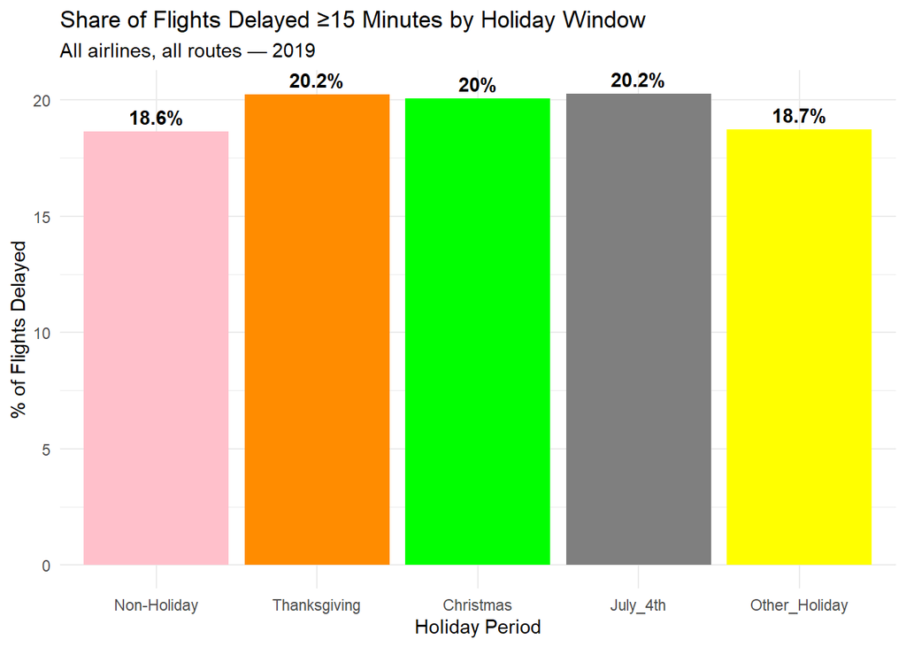

```r
# Flights Delayed ≥15 min by Holiday Period
holiday_summary_overall <- flights_holiday %>%
  group_by(is_holiday) %>%
  summarise(
    avg_arr_delay = mean(arr_delay, na.rm = TRUE),
    pct_delayed   = mean(arr_delay >= 15, na.rm = TRUE) * 100,
    flight_count  = n(),
    .groups = "drop"
  )

ggplot(holiday_summary_overall,
       aes(x = is_holiday, y = pct_delayed, fill = is_holiday)) +
  geom_col(show.legend = FALSE) +
  geom_text(aes(label = paste0(round(pct_delayed, 1), "%")),
            vjust = -0.5, fontface = "bold") +
  scale_fill_manual(values = c(
    "Non-Holiday"  = "pink",
    "Thanksgiving" = "darkorange",
    "Christmas"    = "green",
    "July4th"      = "blue",
    "Other_Holiday"= "yellow"
  )) +
  labs(
    title = "Share of Flights Delayed ≥15 Minutes by Holiday Window",
    subtitle = "All airlines, all routes — 2019",
    x = "Holiday Period", y = "% of Flights Delayed"
  ) +
  theme_minimal()
```

```r
# propagated delays, how much of this flight's arrival delay was inherited
# using tail number (prev_arr_delay),
# versus new delay generated on this leg (dep_delay - prev_arr_delay).

propagation_df <- flights_holiday %>%
  filter(!is.na(prev_arr_delay)) %>%
  mutate(
    # Inherited delay: how much was carried in from previous leg
    inherited_delay = pmax(prev_arr_delay, 0),

    # Freshly generated delay: new delay created on THIS leg
    new_delay = pmax(dep_delay - prev_arr_delay, 0),

    # Total departure delay decomposed
    total_dep_delay = inherited_delay + new_delay
  )

# Inherited vs New Delay by Holiday
propagation_summary <- propagation_df %>%
  group_by(is_holiday) %>%
  summarise(
    avg_inherited_delay = mean(inherited_delay, na.rm = TRUE),
    avg_new_delay       = mean(new_delay,       na.rm = TRUE),
    avg_total_dep_delay = mean(total_dep_delay, na.rm = TRUE),
    pct_inherited       = mean(inherited_delay, na.rm = TRUE) /
                          mean(total_dep_delay, na.rm = TRUE) * 100,
    flight_count        = n(),
    .groups = "drop"
  )

kable(propagation_summary,
      caption = "Propagated vs. Freshly Generated Delays by Holiday Period",
      digits = 2,
      col.names = c("Holiday Period", "Avg Inherited (min)",
                    "Avg New Delay (min)", "Avg Total Dep Delay",
                    "% That Is Inherited", "Flights")) %>%
  kable_styling(bootstrap_options = c("striped", "hover")) %>%
  column_spec(5, bold = TRUE, color = "white",
              background = spec_color(propagation_summary$pct_inherited,
                                      option = "C", direction = -1))
```

Propagated vs. Freshly Generated Delays by Holiday Period

| Holiday Period | Avg Inherited (min) | Avg New Delay (min) | Avg Total Dep Delay | % That Is Inherited | Flights |
| --- | --- | --- | --- | --- | --- |
| Non-Holiday | 13.80 | 14.04 | 27.84 | 49.57 | 6102339 |
| Thanksgiving | 13.23 | 14.35 | 27.57 | 47.96 | 135491 |
| Christmas | 14.07 | 16.16 | 30.23 | 46.56 | 137727 |
| July_4th | 16.44 | 16.29 | 32.73 | 50.23 | 136053 |
| Other_Holiday | 14.06 | 14.28 | 28.34 | 49.63 | 904535 |

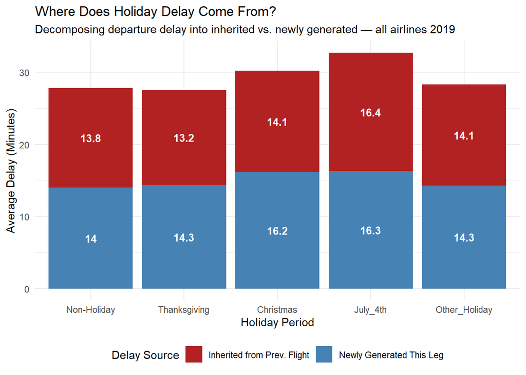

```r
# Stacked Bar — Inherited vs New Delay by Holiday
propagation_long <- propagation_summary %>%
  select(is_holiday, avg_inherited_delay, avg_new_delay) %>%
  pivot_longer(cols = c(avg_inherited_delay, avg_new_delay),
               names_to  = "delay_type",
               values_to = "minutes") %>%
  mutate(delay_type = recode(delay_type,
    "avg_inherited_delay" = "Inherited from Prev. Flight",
    "avg_new_delay"       = "Newly Generated This Leg"
  ))

ggplot(propagation_long,
       aes(x = is_holiday, y = minutes, fill = delay_type)) +
  geom_col(position = "stack") +
  geom_text(aes(label = round(minutes, 1)),
            position = position_stack(vjust = 0.5),
            color = "white", fontface = "bold", size = 3.5) +
  scale_fill_manual(values = c(
    "Inherited from Prev. Flight" = "firebrick",
    "Newly Generated This Leg"    = "steelblue"
  )) +
  labs(
    title = "Where Does Holiday Delay Come From?",
    subtitle = "Decomposing departure delay into inherited vs. newly generated — all airlines 2019",
    x = "Holiday Period", y = "Average Delay (Minutes)",
    fill = "Delay Source"
  ) +
  theme_minimal() +
  theme(legend.position = "bottom")
```

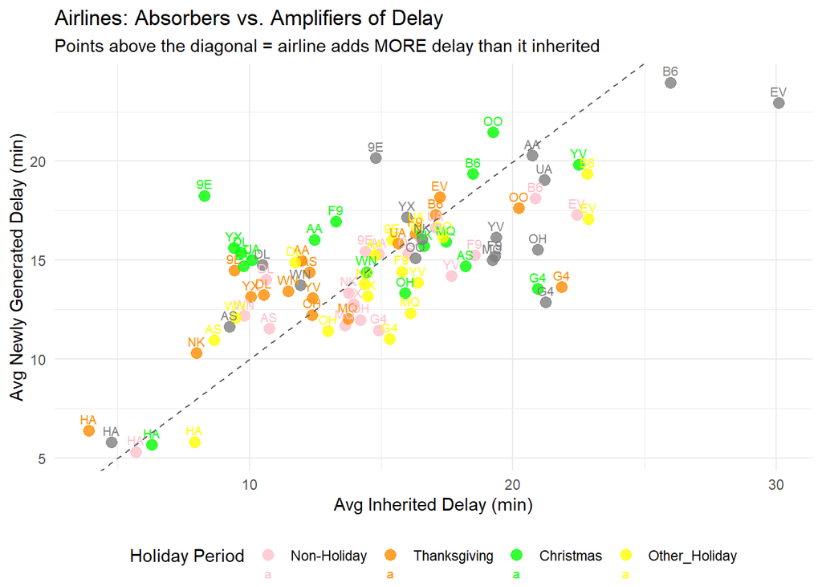

```r
# propagated delay by airline
propagation_airline <- propagation_df %>%
  group_by(reporting_airline, is_holiday) %>%
  summarise(
    avg_inherited = mean(inherited_delay, na.rm = TRUE),
    avg_new       = mean(new_delay,       na.rm = TRUE),
    .groups = "drop"
  )

ggplot(propagation_airline,
       aes(x = avg_inherited, y = avg_new,
           color = is_holiday, label = reporting_airline)) +
  geom_point(size = 3, alpha = 0.8) +
  geom_text(vjust = -0.7, size = 2.8) +
  geom_abline(slope = 1, intercept = 0, linetype = "dashed",
              color = "grey40") +
  scale_color_manual(values = c(
    "Non-Holiday"   = "pink",
    "Thanksgiving"  = "darkorange",
    "Christmas"     = "green",
    "July4th"       = "blue",
    "Other_Holiday" = "yellow"
  )) +
  labs(
    title = "Airlines: Absorbers vs. Amplifiers of Delay",
    subtitle = "Points above the diagonal = airline adds MORE delay than it inherited",
    x = "Avg Inherited Delay (min)",
    y = "Avg Newly Generated Delay (min)",
    color = "Holiday Period"
  ) +
  theme_minimal() +
  theme(legend.position = "bottom")
```